# Breast Cancer Dataset

#### Classify tumors into malignant (cancerous) or benign(non-cancerous) using unsupervised clustering methods

Using this dataset I want to identify malginant tumors while applying dimentionality reduction and clustering methods

dataset: https://www.kaggle.com/datasets/nancyalaswad90/breast-cancer-dataset

```
(-0.5, 599.5, 399.5, -0.5)
```

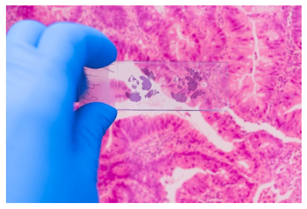

```python
import imageio.v2 as iio
import matplotlib.pyplot as plt

img = iio.imread("cancer_img.jpeg")
plt.imshow(img)
plt.axis('off')

#Source: shutterstock.com
```

The dataset is a collection of measurements of cell nuclei of different biopsies (needle aspirate) done on malignant and beneign tumors. The measured features are:

a) radius (mean of distances from center to points on the perimeter)

b) texture (standard deviation of gray-scale values)

c) perimeter

d) area

e) smoothness (local variation in radius lengths)

f) compactness (perimeter^2 / area - 1.0)

g) concavity (severity of concave portions of the contour)

h) concave points (number of concave portions of the contour)

i) symmetry

j) fractal dimension ("coastline approximation" - 1)

## EDA

- Overview of the data
- Target class balance
- Correlation between the features
- Uniformity of the data

```python
import pandas as pd
import seaborn as sns
import numpy as np
import random
```

```python
df = pd.read_csv("data.csv")
df_og = df.copy()
```

```python
print(df.shape)
df.head()
```

```
(569, 32)
```

|  | id | diagnosis | radius_mean | texture_mean | perimeter_mean | area_mean | smoothness_mean | compactness_mean | concavity_mean | concave_points_mean | ... | radius_worst | texture_worst | perimeter_worst | area_worst | smoothness_worst | compactness_worst | concavity_worst | concave_points_worst | symmetry_worst | fractal_dimension_worst |
| --- | --- | --- | --- | --- | --- | --- | --- | --- | --- | --- | --- | --- | --- | --- | --- | --- | --- | --- | --- | --- | --- |
| 0 | 842302 | M | 17.99 | 10.38 | 122.80 | 1001.0 | 0.11840 | 0.27760 | 0.3001 | 0.14710 | ... | 25.38 | 17.33 | 184.60 | 2019.0 | 0.1622 | 0.6656 | 0.7119 | 0.2654 | 0.4601 | 0.11890 |
| 1 | 842517 | M | 20.57 | 17.77 | 132.90 | 1326.0 | 0.08474 | 0.07864 | 0.0869 | 0.07017 | ... | 24.99 | 23.41 | 158.80 | 1956.0 | 0.1238 | 0.1866 | 0.2416 | 0.1860 | 0.2750 | 0.08902 |
| 2 | 84300903 | M | 19.69 | 21.25 | 130.00 | 1203.0 | 0.10960 | 0.15990 | 0.1974 | 0.12790 | ... | 23.57 | 25.53 | 152.50 | 1709.0 | 0.1444 | 0.4245 | 0.4504 | 0.2430 | 0.3613 | 0.08758 |
| 3 | 84348301 | M | 11.42 | 20.38 | 77.58 | 386.1 | 0.14250 | 0.28390 | 0.2414 | 0.10520 | ... | 14.91 | 26.50 | 98.87 | 567.7 | 0.2098 | 0.8663 | 0.6869 | 0.2575 | 0.6638 | 0.17300 |
| 4 | 84358402 | M | 20.29 | 14.34 | 135.10 | 1297.0 | 0.10030 | 0.13280 | 0.1980 | 0.10430 | ... | 22.54 | 16.67 | 152.20 | 1575.0 | 0.1374 | 0.2050 | 0.4000 | 0.1625 | 0.2364 | 0.07678 |

5 rows × 32 columns

Because we are aiming to train an unsupervised ML model we will drop the `diagnosis` column while training

```python
print("Types of measurements")
set([col.split("_")[0] for col in df.columns if col not in ['id','diagnosis']])
```

```
Types of measurements
```

```
{'area',
 'compactness',
 'concave',
 'concavity',
 'fractal',
 'perimeter',
 'radius',
 'smoothness',
 'symmetry',
 'texture'}
```

```python
print("Adjectives for the measurements")
set([col.split("_")[-1] for col in df.columns if col not in ['id','diagnosis']])
```

```
Adjectives for the measurements
```

```
{'mean', 'se', 'worst'}
```

```python
df.info()
```

```
<class 'pandas.core.frame.DataFrame'>
RangeIndex: 569 entries, 0 to 568
Data columns (total 32 columns):
 #   Column                   Non-Null Count  Dtype
---  ------                   --------------  -----
 0   id                       569 non-null    int64
 1   diagnosis                569 non-null    object
 2   radius_mean              569 non-null    float64
 3   texture_mean             569 non-null    float64
 4   perimeter_mean           569 non-null    float64
 5   area_mean                569 non-null    float64
 6   smoothness_mean          569 non-null    float64
 7   compactness_mean         569 non-null    float64
 8   concavity_mean           569 non-null    float64
 9   concave_points_mean      569 non-null    float64
```

[output cut: 24 more lines]

```python
df.dtypes.value_counts()
```

```
float64    30
int64       1
object      1
dtype: int64
```

The data does not contain any missing data and is type consistent (with the exception of the id which is an int)

```python
df.describe().T
```

|  | count | mean | std | min | 25% | 50% | 75% | max |
| --- | --- | --- | --- | --- | --- | --- | --- | --- |
| id | 569.0 | 3.037183e+07 | 1.250206e+08 | 8670.000000 | 869218.000000 | 906024.000000 | 8.813129e+06 | 9.113205e+08 |
| radius_mean | 569.0 | 1.412729e+01 | 3.524049e+00 | 6.981000 | 11.700000 | 13.370000 | 1.578000e+01 | 2.811000e+01 |
| texture_mean | 569.0 | 1.928965e+01 | 4.301036e+00 | 9.710000 | 16.170000 | 18.840000 | 2.180000e+01 | 3.928000e+01 |
| perimeter_mean | 569.0 | 9.196903e+01 | 2.429898e+01 | 43.790000 | 75.170000 | 86.240000 | 1.041000e+02 | 1.885000e+02 |
| area_mean | 569.0 | 6.548891e+02 | 3.519141e+02 | 143.500000 | 420.300000 | 551.100000 | 7.827000e+02 | 2.501000e+03 |
| smoothness_mean | 569.0 | 9.636028e-02 | 1.406413e-02 | 0.052630 | 0.086370 | 0.095870 | 1.053000e-01 | 1.634000e-01 |
| compactness_mean | 569.0 | 1.043410e-01 | 5.281276e-02 | 0.019380 | 0.064920 | 0.092630 | 1.304000e-01 | 3.454000e-01 |
| concavity_mean | 569.0 | 8.879932e-02 | 7.971981e-02 | 0.000000 | 0.029560 | 0.061540 | 1.307000e-01 | 4.268000e-01 |
| concave_points_mean | 569.0 | 4.891915e-02 | 3.880284e-02 | 0.000000 | 0.020310 | 0.033500 | 7.400000e-02 | 2.012000e-01 |
| symmetry_mean | 569.0 | 1.811619e-01 | 2.741428e-02 | 0.106000 | 0.161900 | 0.179200 | 1.957000e-01 | 3.040000e-01 |
| fractal_dimension_mean | 569.0 | 6.279761e-02 | 7.060363e-03 | 0.049960 | 0.057700 | 0.061540 | 6.612000e-02 | 9.744000e-02 |
| radius_se | 569.0 | 4.051721e-01 | 2.773127e-01 | 0.111500 | 0.232400 | 0.324200 | 4.789000e-01 | 2.873000e+00 |
| texture_se | 569.0 | 1.216853e+00 | 5.516484e-01 | 0.360200 | 0.833900 | 1.108000 | 1.474000e+00 | 4.885000e+00 |
| perimeter_se | 569.0 | 2.866059e+00 | 2.021855e+00 | 0.757000 | 1.606000 | 2.287000 | 3.357000e+00 | 2.198000e+01 |
| area_se | 569.0 | 4.033708e+01 | 4.549101e+01 | 6.802000 | 17.850000 | 24.530000 | 4.519000e+01 | 5.422000e+02 |
| smoothness_se | 569.0 | 7.040979e-03 | 3.002518e-03 | 0.001713 | 0.005169 | 0.006380 | 8.146000e-03 | 3.113000e-02 |
| compactness_se | 569.0 | 2.547814e-02 | 1.790818e-02 | 0.002252 | 0.013080 | 0.020450 | 3.245000e-02 | 1.354000e-01 |
| concavity_se | 569.0 | 3.189372e-02 | 3.018606e-02 | 0.000000 | 0.015090 | 0.025890 | 4.205000e-02 | 3.960000e-01 |
| concave_points_se | 569.0 | 1.179614e-02 | 6.170285e-03 | 0.000000 | 0.007638 | 0.010930 | 1.471000e-02 | 5.279000e-02 |
| symmetry_se | 569.0 | 2.054230e-02 | 8.266372e-03 | 0.007882 | 0.015160 | 0.018730 | 2.348000e-02 | 7.895000e-02 |
| fractal_dimension_se | 569.0 | 3.794904e-03 | 2.646071e-03 | 0.000895 | 0.002248 | 0.003187 | 4.558000e-03 | 2.984000e-02 |
| radius_worst | 569.0 | 1.626919e+01 | 4.833242e+00 | 7.930000 | 13.010000 | 14.970000 | 1.879000e+01 | 3.604000e+01 |
| texture_worst | 569.0 | 2.567722e+01 | 6.146258e+00 | 12.020000 | 21.080000 | 25.410000 | 2.972000e+01 | 4.954000e+01 |
| perimeter_worst | 569.0 | 1.072612e+02 | 3.360254e+01 | 50.410000 | 84.110000 | 97.660000 | 1.254000e+02 | 2.512000e+02 |
| area_worst | 569.0 | 8.805831e+02 | 5.693570e+02 | 185.200000 | 515.300000 | 686.500000 | 1.084000e+03 | 4.254000e+03 |
| smoothness_worst | 569.0 | 1.323686e-01 | 2.283243e-02 | 0.071170 | 0.116600 | 0.131300 | 1.460000e-01 | 2.226000e-01 |
| compactness_worst | 569.0 | 2.542650e-01 | 1.573365e-01 | 0.027290 | 0.147200 | 0.211900 | 3.391000e-01 | 1.058000e+00 |
| concavity_worst | 569.0 | 2.721885e-01 | 2.086243e-01 | 0.000000 | 0.114500 | 0.226700 | 3.829000e-01 | 1.252000e+00 |
| concave_points_worst | 569.0 | 1.146062e-01 | 6.573234e-02 | 0.000000 | 0.064930 | 0.099930 | 1.614000e-01 | 2.910000e-01 |
| symmetry_worst | 569.0 | 2.900756e-01 | 6.186747e-02 | 0.156500 | 0.250400 | 0.282200 | 3.179000e-01 | 6.638000e-01 |
| fractal_dimension_worst | 569.0 | 8.394582e-02 | 1.806127e-02 | 0.055040 | 0.071460 | 0.080040 | 9.208000e-02 | 2.075000e-01 |

[figure not shown]

```python
percentages = (round(df.diagnosis.value_counts(normalize=True)*100,2)).reset_index()
percentages.columns = ['Diagnosis', 'Counts']

fig = sns.barplot(x = percentages['Diagnosis'], y=percentages['Counts'])
fig.bar_label(fig.containers[0], fmt="%.2f%%")

plt.xticks(ticks=[0,1], labels=['Malignant', 'Benign'])
plt.title("Malignant and Benign distribution")
plt.show()
```

There is some class imbalance but it is not too dramatic.

```python
df_og = df.copy()
df['diagnosis'] = [1 if i=='M' else 0 for i in df.diagnosis]
df.drop('id', inplace=True, axis=1)
```

```python
corr_matrix = df.corr(numeric_only=True)
```

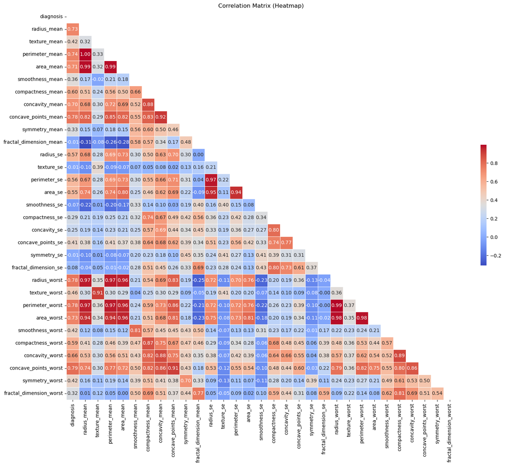

```python
plt.figure(figsize=(18, 15))
mask = np.triu(np.ones_like(corr_matrix, dtype=bool)) #Creates a matrix with "True" values in the upper triangle

sns.heatmap(corr_matrix, mask=mask, cmap='coolwarm', annot=True, fmt=".2f",
            square=True, linewidths=0.5, cbar_kws={"shrink": .3})

plt.title('Correlation Matrix (Heatmap)')
plt.show()
```

```python
# Flatten and filter
corr_pairs = corr_matrix.abs().unstack().sort_values(ascending=False)

# Remove self-correlations (correlation = 1)
filtered = corr_pairs[(corr_pairs < 1) & (corr_pairs > 0.8)]

print(filtered.drop_duplicates())
```

```
perimeter_mean           radius_mean             0.997855
radius_worst             perimeter_worst         0.993708
radius_mean              area_mean               0.987357
perimeter_mean           area_mean               0.986507
area_worst               radius_worst            0.984015
                         perimeter_worst         0.977578
perimeter_se             radius_se               0.972794
perimeter_worst          perimeter_mean          0.970387
radius_worst             radius_mean             0.969539
perimeter_mean           radius_worst            0.969476
perimeter_worst          radius_mean             0.965137
radius_worst             area_mean               0.962746
area_worst               area_mean               0.959213
perimeter_worst          area_mean               0.959120
area_se                  radius_se               0.951830
perimeter_mean           area_worst              0.941550
area_worst               radius_mean             0.941082
perimeter_se             area_se                 0.937655
concavity_mean           concave_points_mean     0.921391
texture_worst            texture_mean            0.912045
concave_points_mean      concave_points_worst    0.910155
compactness_worst        concavity_worst         0.892261
concavity_mean           concavity_worst         0.884103
compactness_mean         concavity_mean          0.883121
compactness_worst        compactness_mean        0.865809
concavity_mean           concave_points_worst    0.861323
perimeter_worst          concave_points_mean     0.855923
concavity_worst          concave_points_worst    0.855434
concave_points_mean      perimeter_mean          0.850977
                         compactness_mean        0.831135
                         radius_worst            0.830318
                         area_mean               0.823269
                         radius_mean             0.822529
perimeter_worst          concave_points_worst    0.816322
compactness_mean         concavity_worst         0.816275
                         concave_points_worst    0.815573
area_se                  area_worst              0.811408
fractal_dimension_worst  compactness_worst       0.810455
concave_points_mean      area_worst              0.809630
smoothness_mean          smoothness_worst        0.805324
fractal_dimension_se     compactness_se          0.803269
concavity_se             compactness_se          0.801268
concave_points_worst     compactness_worst       0.801080
area_mean                area_se                 0.800086
dtype: float64
```

We can see a lot of features have strong correlation with each other. This will make feature reduction essential to improve the model's performance. We can check which features have the highest correlation with the diagnosis:

```python
# Flatten and filter
corr_pairs = corr_matrix['diagnosis'].abs().sort_values(ascending=False)

# Remove self-correlations (correlation = 1)
filtered = corr_pairs[(corr_pairs < 1) & (corr_pairs > 0.7)]

print(filtered.drop_duplicates())
```

```
concave_points_worst    0.793566
perimeter_worst         0.782914
concave_points_mean     0.776614
radius_worst            0.776454
perimeter_mean          0.742636
area_worst              0.733825
radius_mean             0.730029
area_mean               0.708984
Name: diagnosis, dtype: float64
```

We know check the skewness of the different features to check if we need to do data engineering, as standardization of the data is an essential step of PCA.

```python
log_columns = df.skew().sort_values(ascending=False)
log_columns = log_columns.loc[log_columns > 0.75]

log_columns
```

```
area_se                    5.447186
concavity_se               5.110463
fractal_dimension_se       3.923969
perimeter_se               3.443615
radius_se                  3.088612
smoothness_se              2.314450
symmetry_se                2.195133
compactness_se             1.902221
area_worst                 1.859373
fractal_dimension_worst    1.662579
texture_se                 1.646444
area_mean                  1.645732
compactness_worst          1.473555
concave_points_se          1.444678
symmetry_worst             1.433928
concavity_mean             1.401180
fractal_dimension_mean     1.304489
compactness_mean           1.190123
concave_points_mean        1.171180
concavity_worst            1.150237
perimeter_worst            1.128164
radius_worst               1.103115
perimeter_mean             0.990650
radius_mean                0.942380
dtype: float64
```

```python
# The log transformations
for col in log_columns.index:
    df[col] = np.log1p(df[col])
```

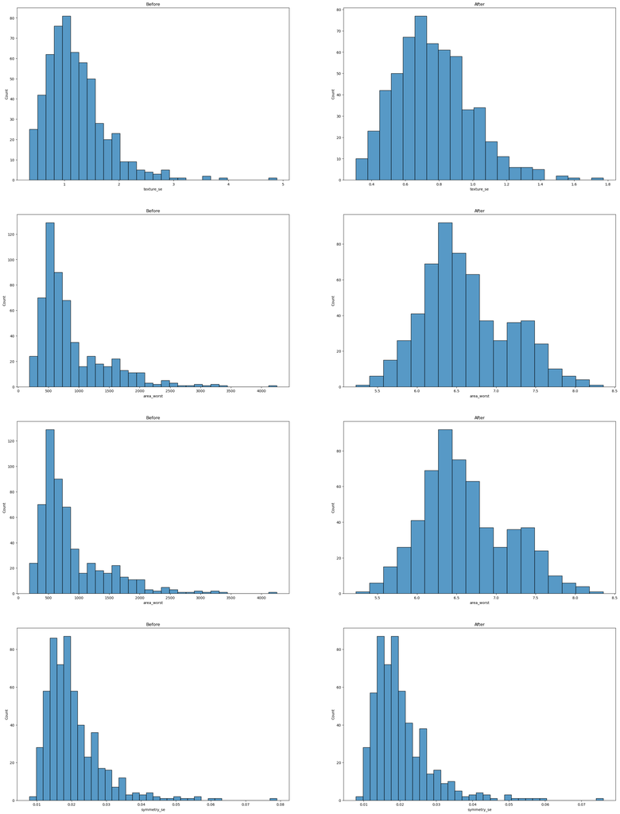

```python
fig, ax = plt.subplots(4,2,figsize=(30,40))

for idx,i in enumerate(random.choices(list(log_columns.index),k=4)):
    sns.histplot(df_og[i], ax=ax[idx,0])
    sns.histplot(df[i], ax=ax[idx,1])
    ax[idx,0].set_title(f'Before')
    ax[idx,1].set_title('After')
plt.show()
```

## PCA

We now need to find the optimal amount of dimentions for the PCA

```python
from sklearn.pipeline import Pipeline
from sklearn.preprocessing import StandardScaler
from sklearn.model_selection import StratifiedShuffleSplit
from sklearn.linear_model import LogisticRegression
from sklearn.metrics import accuracy_score, precision_score, recall_score
from sklearn.decomposition import PCA
from itertools import accumulate
from sklearn.preprocessing import FunctionTransformer
from sklearn.cluster import KMeans
from sklearn.model_selection import train_test_split
```

```python
X = df_og.drop(['diagnosis','id'], inplace=False, axis=1)
y = df.diagnosis
```

```python
pca = PCA()
X_PCA = pd.DataFrame(pca.fit_transform(X), index=X.index, columns=[f'Component {i}' for i in range(pca.n_components_)])
# (Remember it's technically "Projection onto Component {i}")
X_PCA.head()
```

|  | Component 0 | Component 1 | Component 2 | Component 3 | Component 4 | Component 5 | Component 6 | Component 7 | Component 8 | Component 9 | ... | Component 20 | Component 21 | Component 22 | Component 23 | Component 24 | Component 25 | Component 26 | Component 27 | Component 28 | Component 29 |
| --- | --- | --- | --- | --- | --- | --- | --- | --- | --- | --- | --- | --- | --- | --- | --- | --- | --- | --- | --- | --- | --- |
| 0 | 1160.142574 | -293.917544 | 48.578398 | 8.711975 | -32.000486 | -1.265415 | -0.931337 | 0.148167 | -0.745463 | 0.589359 | ... | 0.021189 | 0.000241 | -0.002528 | -0.011560 | 0.005773 | 0.001377 | -0.001982 | 0.001293 | 0.001989 | 0.000704 |
| 1 | 1269.122443 | 15.630182 | -35.394534 | -17.861283 | 4.334874 | 0.225872 | 0.046037 | 0.200804 | 0.485828 | -0.084035 | ... | 0.005237 | 0.021069 | -0.001565 | -0.006968 | -0.006978 | 0.001411 | -0.000083 | -0.001347 | 0.000686 | -0.001061 |
| 2 | 995.793889 | 39.156743 | -1.709753 | -4.199340 | 0.466529 | 2.652811 | 0.779745 | -0.274026 | 0.173874 | -0.186994 | ... | -0.009865 | -0.002394 | 0.004125 | 0.004007 | 0.000709 | -0.003781 | 0.000178 | 0.000018 | -0.000775 | 0.000405 |
| 3 | -407.180803 | -67.380320 | 8.672848 | 11.759867 | -7.115461 | -1.299436 | 1.267304 | -0.060555 | 0.330639 | -0.144155 | ... | 0.011169 | 0.007063 | -0.001537 | -0.007003 | -0.010261 | -0.002899 | 0.000016 | 0.001369 | -0.002139 | -0.001657 |
| 4 | 930.341180 | 189.340742 | 1.374801 | -8.499183 | -7.613289 | -1.021160 | 0.335522 | 0.289109 | -0.036087 | -0.138502 | ... | -0.009916 | 0.010269 | -0.002204 | -0.002764 | 0.002455 | 0.001665 | 0.003290 | 0.000273 | 0.001783 | 0.000327 |

5 rows × 30 columns

```python
def plot_explained_variance(pca):
    # This function graphs the accumulated explained variance ratio for a fitted PCA object.
    acc = [*accumulate(pca.explained_variance_ratio_)]
    fig, ax = plt.subplots(1, figsize=(50, 20))
    ax.stackplot(range(pca.n_components_), acc)
    ax.scatter(range(pca.n_components_), acc, color='black')
    ax.set_ylim(0, 1)
    ax.set_xlim(0, pca.n_components_-1)
    ax.tick_params(axis='both', labelsize=36)
    ax.set_xlabel('N Components', fontsize=48)
    ax.set_ylabel('Accumulated explained variance', fontsize=48)
    plt.tight_layout()
    plt.show()
```

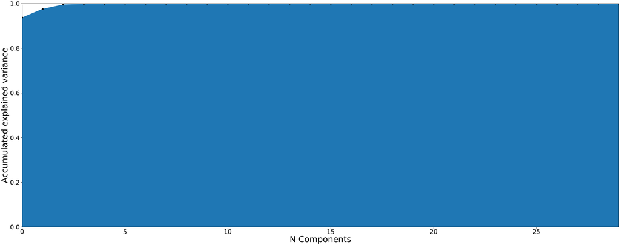

```python
plot_explained_variance(pca)
```

```python
threshold = 0.99
num = next(i for i, x in enumerate(accumulate(pca.explained_variance_ratio_), 1) if x >= threshold)
print(f'We can keep the first {num} components and discard the other {pca.n_components_-num},')
print(f'keeping >={100 * threshold}% of the explained variance!')
```

```
We can keep the first 3 components and discard the other 27,
keeping >=99.0% of the explained variance!
```

[figure not shown]

```python
ax = plt.figure(figsize=(10,10)).add_subplot(projection='3d')
ax.scatter(X_PCA.iloc[:,0], X_PCA.iloc[:,1], X_PCA.iloc[:,2], c=df.diagnosis, cmap='viridis')

plt.xlabel("PC1")
plt.ylabel("PC2")
plt.title("K-Means Clusters (PCA-reduced)")
plt.show()
```

## Testing out different models

### First a simple logistic regression

```python
from sklearn.mixture import GaussianMixture
from scipy.optimize import linear_sum_assignment
from sklearn.metrics import confusion_matrix
from sklearn.cluster import MeanShift, estimate_bandwidth
```

```python
def map_clusters(y_true, y_pred):
    """Map cluster labels to match true labels."""
    cm = confusion_matrix(y_true, y_pred)
    row_ind, col_ind = linear_sum_assignment(-cm)  # maximize total match
    label_map = dict(zip(col_ind, row_ind))

    return np.vectorize(label_map.get)(y_pred)

def get_avg_score(n, estimator=None):
    sss = StratifiedShuffleSplit(n_splits=5, random_state=80, test_size=0.1)

    if estimator==None:
        estimator = LogisticRegression(solver='liblinear')
    pipe = [
        ('log1p', FunctionTransformer(np.log1p)),
        ('pca', PCA(n_components=0.99)),
        ('estimator', estimator)
    ]
    pipe = Pipeline(pipe)
    acc_scores = []
    prec_scores = []
    rec_scores = []

    for train_index, test_index in sss.split(X, y):
        X_train, X_test = X.loc[train_index], X.loc[test_index]
        y_train, y_test = y.loc[train_index], y.loc[test_index]
        pipe.fit(X_train, y_train)
        y_hat = pipe.predict(X_test)

        # If unsupervised (e.g., KMeans), map clusters to class labels
        if isinstance(pipe['estimator'], (KMeans, GaussianMixture, MeanShift)):
            y_hat = map_clusters(y_test, y_hat)


        acc_scores.append(accuracy_score(y_test, y_hat))
        prec_scores.append(precision_score(y_test, y_hat))
        rec_scores.append(recall_score(y_test, y_hat))



    print(f'Mean accuracy: {np.mean(acc_scores)}')
    print(f'Mean precision: {np.mean(prec_scores)}')
    print(f'Mean recall: {np.mean(rec_scores)}')
    return acc_scores, prec_scores, rec_scores

acc_scores, prec_scores, rec_scores = get_avg_score(3)
```

```
Mean accuracy: 0.968421052631579
Mean precision: 0.9722943722943723
Mean recall: 0.9428571428571428
```

### K-Means

```python
acc_scores_kmeans, prec_scores_kmeans, rec_scores_kmeans = get_avg_score(3, KMeans(n_clusters=2, random_state=50, n_init=100))
```

```
Mean accuracy: 0.8842105263157893
Mean precision: 0.9741666666666667
Mean recall: 0.7047619047619047
```

### MeanShift

This model will have a harder time because we are not specifying the number of clusters we want.

```python
bandwidth = estimate_bandwidth(X, quantile=.06)
bandwidth
acc_scores_kmeans2, prec_scores_kmeans2, rec_scores_kmeans2 = get_avg_score(3, MeanShift(bandwidth=bandwidth,bin_seeding=True))
```

```
Mean accuracy: 0.631578947368421
Mean precision: 0.0
Mean recall: 0.0
```

### Gaussian Mixture

```python
acc_scores_gaus, prec_scores_gaus, rec_scores_gaus = get_avg_score(3, GaussianMixture(n_components=2, random_state=42))
```

```
Mean accuracy: 0.9192982456140351
Mean precision: 0.8365797101449275
Mean recall: 0.9714285714285713
```